# Part II - Ford Go Bike

## by Mohamed Najib Adan

## Investigation Overview

- Age isn't an excuse for not exercising.
- Age, Gender and whether if you are customer or a subscriber is a key factor on ride duration.
- Are there peak hours and slow days?

## Dataset Overview

This data set includes information about individual rides made in a bike-sharing system covering the greater San Francisco Bay area. It contains ride information like ride duration length, age and gender of the rider and where the ride started and ended.

## Age is not an excuse for not riding a bike!

Not only is riding a bike really good way to enjoy the scenery while exercising it's also not as physically demanding as compared to running.

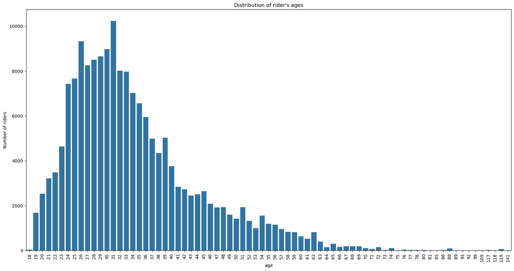

Even though majority of the riders are aged between their mid to late 20s to early 30s we see riders older than 60 years old to even 119 years old!

You can still get on a bike no matter the age and still be young at heart!

### Age, Gender and whether if you are customer or a subscriber is a key factor on ride duration.

#### Age

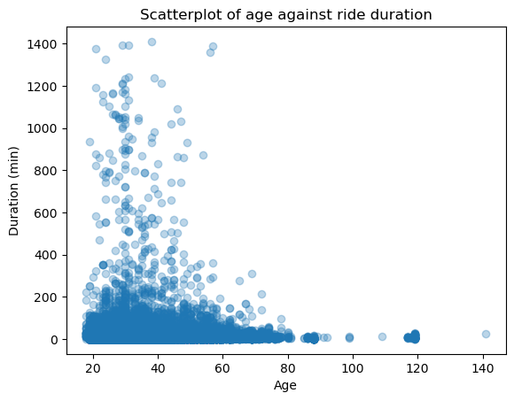

Riders between the age range 20-60 would go for longer rides compared to riders older than 60 years old.

#### Gender

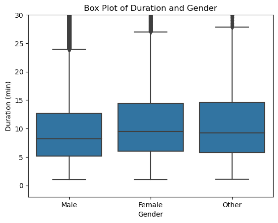

Even though male riders dominate this dataset, male riders take shorter rides (~8 minutes) compared to the other genders.

Female and riders who identified themselves as Other take longer rides.

#### User Type

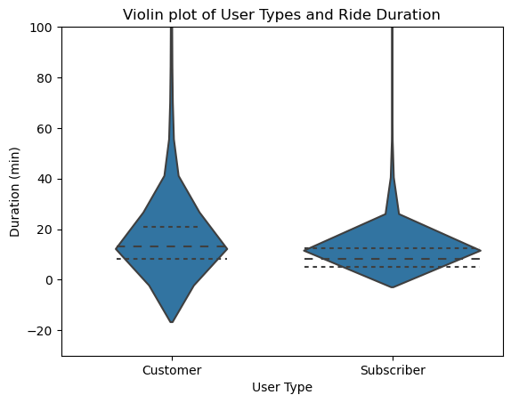

Customers tend to go on longer trips, the median for customers meets nicely with the subscriber's 3rd quartile.

### Are there peak hours and slow days?

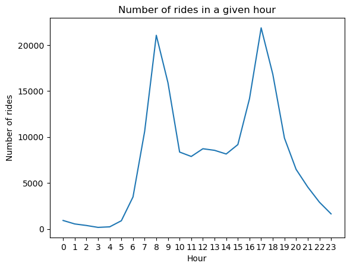

We can see peak hours at 8am and 5pm which fits nicely during rush hours when people are heading to work and leaving work. There is also a slight spike at around noon.

#### Are there Slow days?

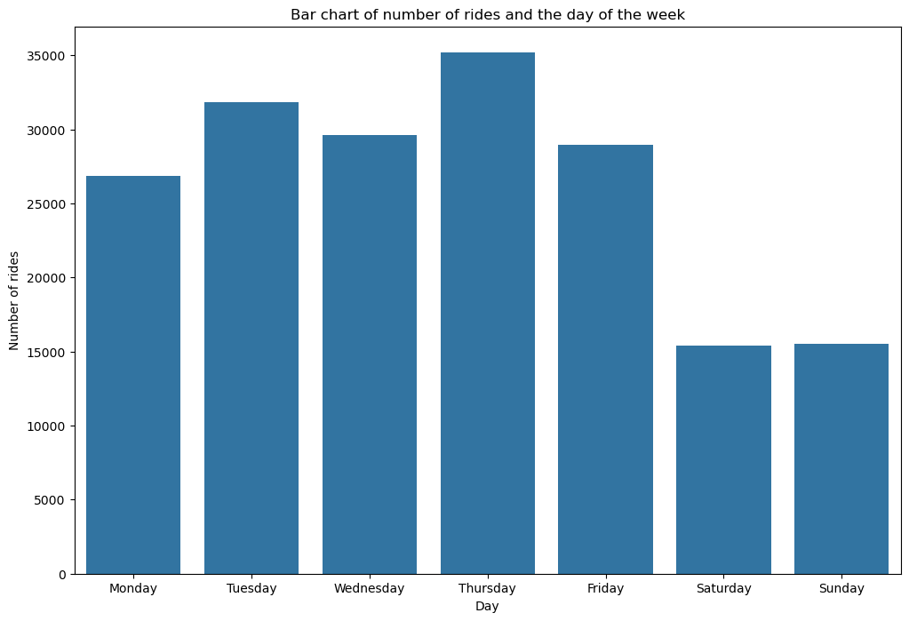

Thursday had the most number of rides with the weekend having the least number of rides.